# Label

# Labels show text

You can use the `Label` node to show simple text to the player. The node includes many options to align and position your text as needed.

This node is integral to show information in your GUI, logs, menus, and dialogue boxes, to name just a few!

To show animated or multicolored text and formats like bold and italics, you should use a `RichTextLabel` instead.

In this guide, you will learn:

- How to create a `Label` and set its text.
- How to set the text of a `Label` in code.
- How to use vertical and horizontal alignments.
- How to animate writing text to a label using `percent_visible`.

Contents:

- Setting up a Label
- Label’s key features
  - Setting the boundaries of your Label
  - Wrapping and clipping text
- How to use a Label in practice
  - Set a Label’s text from code
  - Set a label’s alignment
  - Animate writing text
- Your questions
  - Why are there line breaks in my text?
  - How can I edit long paragraphs in the editor?
  - How can I change the appearance of my text?

## Setting up a Label

1. Add the `Label` to your scene.
2. Set the text property to the words you want to show.
3. Position your label and set the `rect_size` and alignment to make the best use of your space.

## Label’s key features

The `Label` node gives you properties to display and align some text, which live at the top of the *Inspector*.

They’re mostly self-explanatory, so here, we’re going to focus on how to control the textbox’s extents and wrap or clip text automatically.

### Setting the boundaries of your Label

Two properties are responsible for the size of your `Label`, like most `Control` nodes:

1. `rect_size` determines how large your `Label` will be.
2. `rect_min_size` forces the node’s bounding box to be greater or equal to this property.

`Control` nodes like the `Label` are positioned relative to their parent using anchors.

To make a label fill its parent, you can use the *Layout -> Full Rect* preset. You can find the menu in the toolbar.

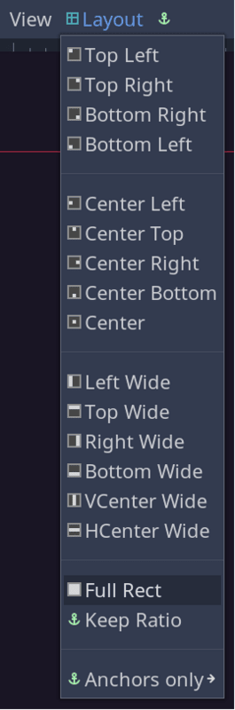

This will update all the node’s anchor and margin properties.

### Wrapping and clipping text

You can wrap text automatically by toggling on `autowrap`.

This makes it so whenever text exceeds the label’s `rect_size.x`, words continue on a new line.

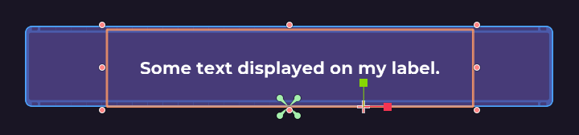

Note: if there isn’t enough vertical space, the `rect_size` of your label will increase on the y axis as you add new lines.

Should you want to hide text overflowing outside the boundaries, you can toggle on the `clip_text` property instead.

## How to use a Label in practice

### Set a Label’s text from code

When selecting a `Label` in the editor, the first property that appears in the *Inspector*, *Text*, will let you type the text you want to show.

If you want to change your text contextually, you need to change the `text` property using a script.

```
var name := "Barry"
$Label.text = "Hello " + name
```

The value you set `Label.text` to needs to be of type `String`. You can convert other types to a string with the `str()` function.

```
var score := 500
$Label.text = str(score)
```

Strings have many functions to include variables in a sentence.

For instance, `format()` takes a dictionary and lets you print the dictionary keys straight into a string.

```
func _process(delta: float) -> void:
    # OS.get_time() returns a dictionary with keys from seconds to years.
    $Label.text = "And this one tells time:\n{hour}:{minute}:{second}".format(
        OS.get_time()
    )
```

To get a list of all string formatting features, head to the manual: [GDScript format string reference](https://docs.godotengine.org/en/stable/getting_started/scripting/gdscript/gdscript_format_string.html).

### Set a label’s alignment

Labels have four alignment options, both horizontally and vertically.

These are best set in the editor using the *Align* and *Valign* properties.

| align (horizontal) | valign (vertical) |
| --- | --- |
| left | top |
| right | bottom |
| center | center |
| fill | fill |

You can update these alignments in code using constants defined in the `Label` class:

```
$Label.align = Label.ALIGN_CENTER
```

This can be a useful option to allow users to customize alignment. A reader may want to choose between justified (fill) and left-aligned text in a reading application.

Fill is the most unique option. The text spreads out to fill the label with even spacing so that opposite sides have a clean, distinct edge. This is also known as justified text, and it is common for text in a thin container.

### Animate writing text

Labels have two properties specifically to animate text in dialog boxes: `percent_visible` and `visible_characters`.

`percent_visible` varies from `0.0` to `1.0`. With a value of `0.5`, fifty percent of the `text` will be visible.

We can animate this property with an `AnimationPlayer` or a `Tween`, to make characters appear one at a time.

```
var write_speed := 33.0

$Tween.interpolate_property($Label, "percent_visible", 0.0, 1.0, len($Label.text) / write_speed)
$Tween.start()
```

See the `Tween` node guide to learn more about using that node.

`visible_characters` has a purpose similar to `percent_visible` except it varies from `0` to the number of characters in your text.

This can be helpful to wait for a different length of time depending on what characters you have revealed to better animate punctuation and control display speed in languages with few characters, like Chinese.

## Your questions

### Why are there line breaks in my text?

Line breaks can be caused by `autowrap` or by having carriage returns in your `text` property.

In the editor, expanding your text view can make new lines much easier to see.

You can introduce new lines in the *Text* property by pressing enter in the *Inspector*, or using the newline character `\n` in code.

### How can I edit long paragraphs in the editor?

The Godot editor has an expand button on the right side of the text property that will open it in a much larger view for easier editing.

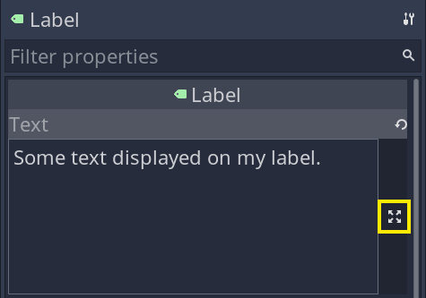

### How can I change the appearance of my text?

With all aesthetic changes in Godot’s UI nodes, you should create a theme resource to share styles between multiple nodes.

For a `Label,` a theme can determine its font, background appearance, outline and shadow colors, shadow positioning, and vertical offset.

See this link for more information about [using themes](https://docs.godotengine.org/en/stable/tutorials/ui/gui_skinning.html).